# Exam 2

Jenni Kane

3/22/2021

Question 1.

```r
data<-read.csv("Exam 2 Data.csv")
head(data)
```

```
##    y          x1          x2 x3
## 1  2  1.37034210 -0.66615843  b
## 2  2 -0.70417232 -0.03705622  c
## 3  4 -0.04223752 -1.53148692  c
## 4  9 -0.56711072 -0.06529335  b
## 5  1  0.31189773  0.81650472  a
## 6 13 -0.35994479 -0.80042308  b
```

Question 2

```r
fit<-glm(formula = y ~ x1*x2+x3, family = poisson, data = data)
summary(fit)
```

```
##
## Call:
## glm(formula = y ~ x1 * x2 + x3, family = poisson, data = data)
##
## Deviance Residuals:
##     Min       1Q   Median       3Q      Max
## -2.3620  -0.6973  -0.1007   0.5236   2.6779
##
## Coefficients:
##             Estimate Std. Error z value Pr(>|z|)
## (Intercept)  1.13258    0.08540  13.262  < 2e-16 ***
## x1          -1.03491    0.05019 -20.620  < 2e-16 ***
## x2          -0.90839    0.06977 -13.021  < 2e-16 ***
## x3b          0.37532    0.09246   4.059 4.92e-05 ***
## x3c         -0.88354    0.12072  -7.319 2.50e-13 ***
## x1:x2       -0.28868    0.05142  -5.614 1.98e-08 ***
## ---
## Signif. codes:  0 '***' 0.001 '**' 0.01 '*' 0.05 '.' 0.1 ' ' 1
##
## (Dispersion parameter for poisson family taken to be 1)
##
##     Null deviance: 720.551  on 99  degrees of freedom
## Residual deviance:  89.088  on 94  degrees of freedom
## AIC: 392.86
##
## Number of Fisher Scoring iterations: 5
```

```r
b<-coef(fit)
b
```

```
## (Intercept)          x1          x2         x3b         x3c       x1:x2
##   1.1325781  -1.0349058  -0.9083868   0.3753215  -0.8835413  -0.2886813
```

Question 3: Interpret the effect of variable x1 when x2 = -1

```r
#effective slope of x1, when x2=-1
ex1<-b[2]+b[6]*-1
ex1
```

```
##         x1
## -0.7462245
```

The log proportional change in expected count decreases by 0.75 for every 1-unit increase in x1.

Question 4. Plot expected counts ±90% confidence intervals over the observed range of variable x1. Assume variable when x2 = -1 and category “a”.

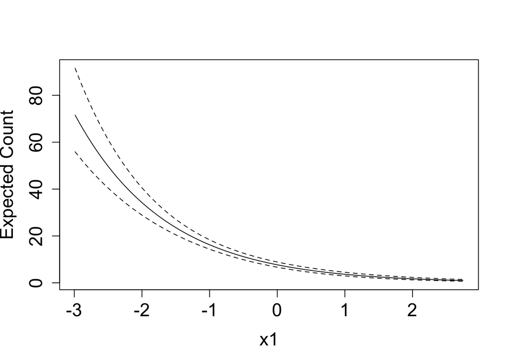

```r
new<-data.frame(
  x1=seq(min(data$x1), max(data$x1), length.out = 100),
  x2 = -1,
  x3 = factor('a', levels = c('a', 'b', 'c'))
)
predict<-predict.glm(fit, new, 'link', se.fit=T)
lo<-exp(predict$fit - qnorm(0.95) * predict$se.fit)
hi<-exp(predict$fit + qnorm(0.95) * predict$se.fit)

plot(y = exp(predict$fit), x = new$x1, xlab = 'x1',
     ylab = 'Expected Count', cex.axis = 1.5, cex.lab = 1.5,
     ylim=c(min(lo), max(hi)), type = 'l')
lines(x=new$x1, y = lo, lty = 2)
lines(x=new$x1, y = hi, lty = 2)
```

Question 5. Interpret the effect of variable x3

```r
exp(b[4])
```

```
##      x3b
## 1.455459
```

The difference in expected count between categories b and a is 1.46.

```r
exp(b[5])
```

```
##       x3c
## 0.4133166
```

The difference in expected count between categories c and a is 0.41.

Question 6.

```r
library(multcomp)
mx1<-mean(data$x1)
```

```r
mx2<-mean(data$x2)

mx1*mx2
```

```
## [1] -0.004994622
```

```r
b
```

```
## (Intercept)          x1          x2         x3b         x3c       x1:x2
##   1.1325781  -1.0349058  -0.9083868   0.3753215  -0.8835413  -0.2886813
```

```r
m<-matrix(c(0,-.1320536, 0.03782269, -1, 1, -0.00499462), nrow = 1)
cnt<-glht(fit, m)
summary(cnt, test = adjusted('none'))
```

```
##
##   Simultaneous Tests for General Linear Hypotheses
##
## Fit: glm(formula = y ~ x1 * x2 + x3, family = poisson, data = data)
##
## Linear Hypotheses:
##        Estimate Std. Error z value Pr(>|z|)
## 1 == 0  -1.1551     0.1184  -9.759   <2e-16 ***
## ---
## Signif. codes:  0 '***' 0.001 '**' 0.01 '*' 0.05 '.' 0.1 ' ' 1
## (Adjusted p values reported -- none method)
```

We can reject this null hypothesis and say that the difference in log expected count between levels b and c is not zero.

Question 7. Derive the test statistic and p-value associated with the interaction between x1 and x2. What is the null hypothesis? Do we reject or fail to reject this null hypothesis? Defend your answer.

```r
s<-summary(fit)[['coefficients']][,2]
s
```

```
## (Intercept)          x1          x2         x3b         x3c       x1:x2
##  0.08539737  0.05018932  0.06976578  0.09246113  0.12072368  0.05142101
```

```r
ts<-b[6]/s[6]
ts
```

```
##     x1:x2
## -5.614074
```

```r
pnorm(-1*abs(ts))*2
```

```
##        x1:x2
## 1.976182e-08
```

Interpretation: Our null hypothesis was that the slope coefficient for the interaction between x1 and x2 is 0. Since our p value is very small, we have strong evidence that the value of x1 depends on that of x2.

Question 8:

```r
dbinom(c(1,0), size = 1, prob=(plogis(-2)))
```

```
## [1] 0.1192029 0.8807971
```

Question 9: Bernoulli random variables take on values between 0 and 1, representing the probability of “success” in trials. Acceptable values are bounded between 0 and 1. Our link function, in this case the logit link, allows us to map a bounded quantity and map it to the real number line. Since we usually want to do the opposite, that is, map a number from the real number line to a probability between 0 and 1, we use the inverse logit link.

Question 10: We must assume asymptotic normality, or that they are Gaussian, with a mean of 0 and a standard deviation of 1.